# HW4

Alice Friedman

9/26/2018

## Step 1: Read CSV file from web, review data

```r
raw.flights <- read.csv("https://raw.githubusercontent.com/aliceafriedman/DATA607_HW4/master/a_flights.csv", sep=",", header=TRUE, stringsAsFactors=FALSE)

glimpse(raw.flights)
```

```
## Observations: 5
## Variables: 7
## $ X             <chr> "Alasaka", "", "", "AM WEST", ""
## $ X.1           <chr> "On time", "Delayed", "", "On time", "Delayed"
## $ Los.Angeles   <int> 497, 62, NA, 694, 117
## $ Phoenix       <int> 221, 12, NA, 4840, 415
## $ San.Diego     <int> 212, 20, NA, 383, 65
## $ San.Francisco <int> 503, 102, NA, 320, 129
## $ Seattle       <int> 1841, 305, NA, 201, 61
```

## Step 2: Add missing column names, remove blank row

```r
# Add column names where missing, remove blank row
flights <- raw.flights %>%
  rename("Airline"=X, "Status"=X.1) %>%
  na.omit() %>%
  glimpse()
```

```
## Observations: 4
## Variables: 7
## $ Airline       <chr> "Alasaka", "", "AM WEST", ""
## $ Status        <chr> "On time", "Delayed", "On time", "Delayed"
## $ Los.Angeles   <int> 497, 62, 694, 117
## $ Phoenix       <int> 221, 12, 4840, 415
## $ San.Diego     <int> 212, 20, 383, 65
## $ San.Francisco <int> 503, 102, 320, 129
## $ Seattle       <int> 1841, 305, 201, 61
```

## Step 3: Add missing data to “Airline” variable

```r
#Note: This is an easy place to introduce errors into the dataset!
#This would also not work wel for a larger data set.
flights$Airline[2] <- "Alaska"
flights$Airline[4] <- "AM WEST"
glimpse(flights)
```

```
## Observations: 4
## Variables: 7
## $ Airline       <chr> "Alasaka", "Alaska", "AM WEST", "AM WEST"
## $ Status        <chr> "On time", "Delayed", "On time", "Delayed"
## $ Los.Angeles   <int> 497, 62, 694, 117
## $ Phoenix       <int> 221, 12, 4840, 415
## $ San.Diego     <int> 212, 20, 383, 65
## $ San.Francisco <int> 503, 102, 320, 129
## $ Seattle       <int> 1841, 305, 201, 61
```

The above is an easy way to introduce errors into the data*, and won’t work well in larger dataset. Is there a better way to do it?

```r
i <- 2
while(i <= length(flights$Airline)) {
  if(flights$Status[i]=="Delayed"){
    flights$Airline[i] <- flights$Airline[i-1]
    }
  i <- i+2
}
glimpse(flights)
```

```
## Observations: 4
## Variables: 7
## $ Airline       <chr> "Alasaka", "Alasaka", "AM WEST", "AM WEST"
## $ Status        <chr> "On time", "Delayed", "On time", "Delayed"
## $ Los.Angeles   <int> 497, 62, 694, 117
## $ Phoenix       <int> 221, 12, 4840, 415
## $ San.Diego     <int> 212, 20, 383, 65
## $ San.Francisco <int> 503, 102, 320, 129
## $ Seattle       <int> 1841, 305, 201, 61
```

*Note, in fact, that the data in flights$Airline doesn’t match! There is an error in the CSV, which we will correct below.

```r
flights$Airline <- gsub("Alasaka", "Alaska", flights$Airline)
```

## Step 4: Gather flights data to analyze delay between airlines

```r
flights.long <- flights %>%
  gather(key = city, value = count, Los.Angeles, Phoenix, San.Diego, San.Francisco, Seattle) %>%
  glimpse()
```

```
## Observations: 20
## Variables: 4
## $ Airline <chr> "Alaska", "Alaska", "AM WEST", "AM WEST", "Alaska", "A...
## $ Status  <chr> "On time", "Delayed", "On time", "Delayed", "On time",...
## $ city    <chr> "Los.Angeles", "Los.Angeles", "Los.Angeles", "Los.Ange...
## $ count   <int> 497, 62, 694, 117, 221, 12, 4840, 415, 212, 20, 383, 6...
```

#### Compare overall delay records

First, we will compare the overall record for each airline. Overall, AM WEST flys substantially more flights overall, and has more flights with delays, but as a percentage of all flights does slightly better than Alaska. This seems like AM WEST is your better bet to avoid delays!

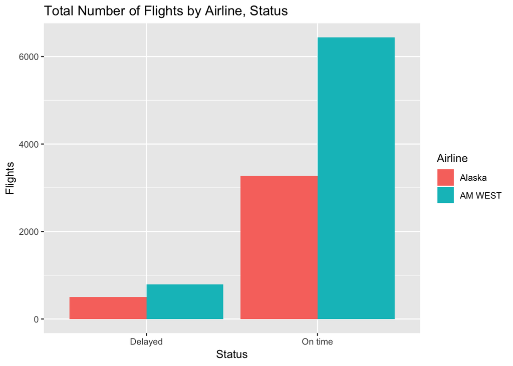

```r
compare.all <- flights.long %>%
  select(-city) %>%
  group_by(Airline) %>%
  mutate(All.Flights = sum(count)) %>%
  group_by(Airline, Status) %>%
  mutate(Flights = sum(count), Percent.By.Status = Flights/All.Flights*100) %>%
  group_by(Airline, Status, Flights, Percent.By.Status) %>%
  summarise()

#Graph number of flights by status, airline
ggplot(compare.all, aes(x=Status, y=Flights, fill=Airline))+geom_col(position = "Dodge")+
  ggtitle("Total Number of Flights by Airline, Status")
```

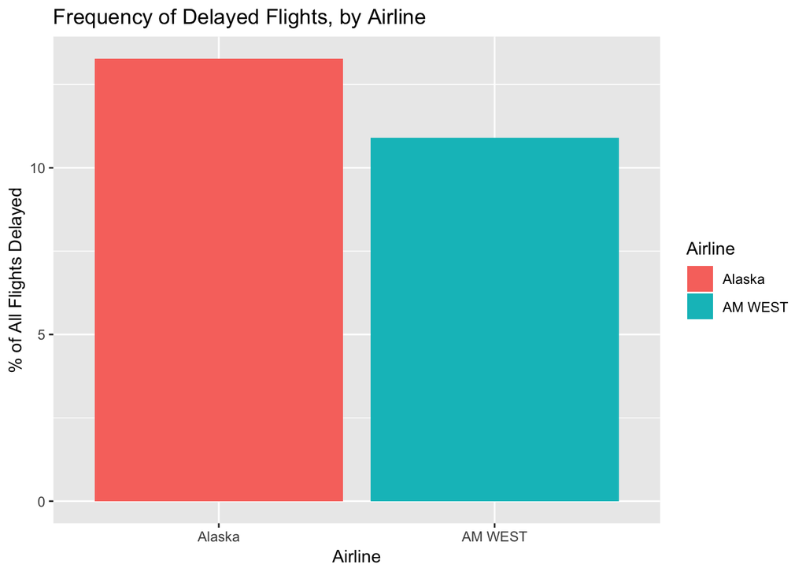

```r
#Graph proportion of all flights by status, airline
compare.all %>% filter(Status=="Delayed") %>%
  ggplot(aes(x=Airline, y=Percent.By.Status, fill=Airline))+geom_col()+
  ggtitle("Frequency of Delayed Flights, by Airline")+
  ylab("% of All Flights Delayed")
```

#### Compare Delay Frequency by City

Just to be sure, we will compare the frequency of delayed flights arriving in each city. Per the data below, your best bet is *actually* always to take Alaska, unless you are flying equally to all cities!

Looks like the high number of delayed flights going into Seattle may be skewing the overall numbers.

```r
compare.by.city <- flights.long %>%
  group_by(Airline, city) %>%
  mutate(
    City.Flights = sum(count),
    Status.Freq.By.City = count/City.Flights*100,
    Delayed.Flights = count) %>%
  filter(Status == "Delayed") %>%
  select(-Status, -City.Flights, -count) %>%
  arrange(city) %>%
  as_tibble()

compare.by.city
```

```
## # A tibble: 10 x 4
## # Groups:   Airline, city [10]
##    Airline city          Status.Freq.By.City Delayed.Flights
##    <chr>   <chr>                       <dbl>           <int>
##  1 Alaska  Los.Angeles                 11.1               62
##  2 AM WEST Los.Angeles                 14.4              117
##  3 Alaska  Phoenix                      5.15              12
##  4 AM WEST Phoenix                      7.90             415
##  5 Alaska  San.Diego                    8.62              20
##  6 AM WEST San.Diego                   14.5               65
##  7 Alaska  San.Francisco               16.9              102
##  8 AM WEST San.Francisco               28.7              129
##  9 Alaska  Seattle                     14.2              305
## 10 AM WEST Seattle                     23.3               61
```

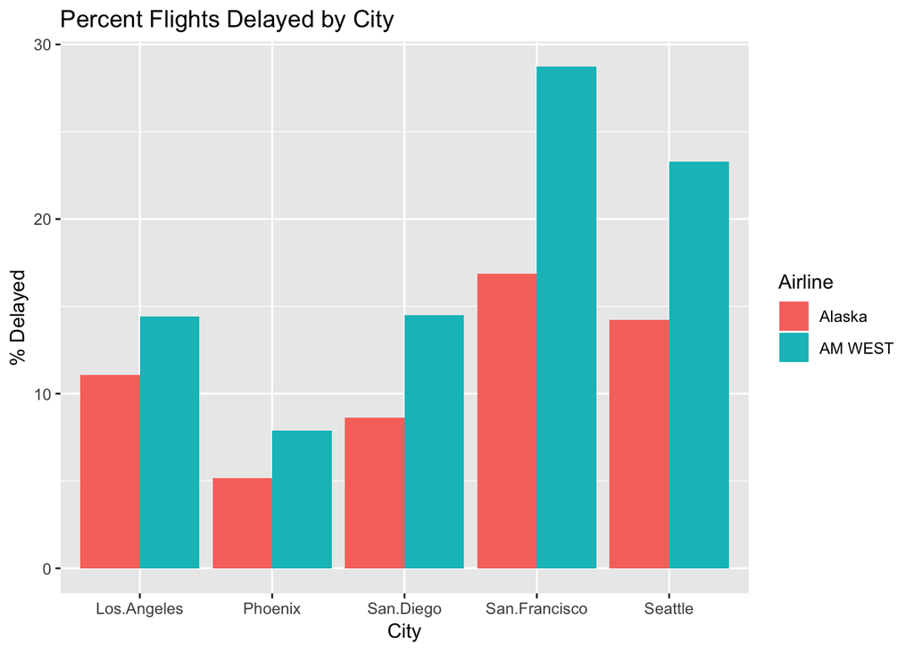

```r
ggplot(compare.by.city,
       aes(x=city, y=Status.Freq.By.City, fill=Airline))+
  geom_col(position = "dodge")+
  ggtitle("Percent Flights Delayed by City")+
  xlab("City")+
  ylab("% Delayed")
```